# R Notebook

```r
library(rvg)
```

Aby stworzyć prezentację powerpoint należy zacząć od funckji `read_pptx()`

- jeżeli użyjemy ją w następujący sposób: `prezentacja <- read_pptx()` to tworzymy pustą prezentację z domyślnym szablonem
- jeżeli użyjemy ją w następujący sposób `prezentacja <- read_pptx(path="prez.pptx")` to utworzymy prezentację z szablonem z tego pliku

```r
prezentacja <- read_pptx()
class(prezentacja)
```

```
[1] "rpptx"
```

Funkcja `layout_summary` zwraca podsumowanie jakie dostępne są układy slajdów w obiekcie, który utworzyliśmy.

| layout | master |
| --- | --- |
| Title Slide | Office Theme |
| Title and Content | Office Theme |
| Section Header | Office Theme |
| Two Content | Office Theme |
| Comparison | Office Theme |
| Title Only | Office Theme |
| Blank | Office Theme |

Wczytajmy szablon z moodle

```r
prez <- read_pptx(path = "../data-raw/prezentacja-przyklad.pptx")
layout_summary(prez)
```

| layout | master |
| --- | --- |
| Title Slide | Civic |
| Title and Vertical Text | Civic |
| Vertical Title and Text | Civic |
| Title and Content | Civic |
| Section Header | Civic |
| Two Content | Civic |
| Comparison | Civic |
| Title Only | Civic |
| Blank | Civic |
| Content with Caption | Civic |

[output cut: 1 more lines]

Jaka jest zasada tworzenia slajdów PowerPoint z poziomu R

- tworzymy plik (`read_pptx()`) `%>%`
  - dodajemy slajd (`add_slide()`) `%>%`
    - uzupełniamy slajd (`ph_*`) `%>%`
    - uzupełniamy slajd (`ph_*`) `%>%`
    - uzupełniamy slajd (`ph_*`) `%>%`
    - uzupełniamy slajd (`ph_*`) `%>%`
  - dodajemy slajd (`add_slide()`) `%>%`
    - uzupełniamy slajd (`ph_*`) `%>%`
  - dodajemy slajd (`add_slide()`) `%>%`
  - uzupełniamy slajd (`ph_*`) `%>%`
- zapisujemy do pliku (`print()`)

```r
prezentacja
```

[output not shown]

| layout | master |
| --- | --- |
| Title Slide | Office Theme |
| Title and Content | Office Theme |
| Section Header | Office Theme |
| Two Content | Office Theme |
| Comparison | Office Theme |
| Title Only | Office Theme |
| Blank | Office Theme |

```r
prezentacja
```

```
pptx document with 1 slide(s)
Available layouts and their associated master(s) are:
```

| layout | master |
| --- | --- |
| Title Slide | Office Theme |
| Title and Content | Office Theme |
| Section Header | Office Theme |
| Two Content | Office Theme |
| Comparison | Office Theme |
| Title Only | Office Theme |
| Blank | Office Theme |

Dodamy slajd z tytułem oraz treścią, która będzie listą wypunktowaną (bullets)

```r
prezentacja <- prezentacja %>%
  add_slide(layout = "Title and Content", master = "Office Theme") %>%
    ph_with(value = "Najważniejsze klasy w R",
            location = ph_location_type(type = "title")) %>%
    ph_with(value = c("data.frame", "list", "vector", "matrix"),
            location = ph_location_type(type = "body"))


prezentacja
```

```
pptx document with 2 slide(s)
Available layouts and their associated master(s) are:
```

| layout | master |
| --- | --- |
| Title Slide | Office Theme |
| Title and Content | Office Theme |
| Section Header | Office Theme |
| Two Content | Office Theme |
| Comparison | Office Theme |
| Title Only | Office Theme |
| Blank | Office Theme |

```r
print(prezentacja, target = "../reports/prezentacja-zajecia.pptx")
```

Ostatni slajd z podziękowaniem

```r
prezentacja <- prezentacja %>%
  add_slide(layout = "Section Header", master = "Office Theme") %>%
  ph_with(value = "Dziękuję za uwagę", location =  ph_location_type(type = "title")) %>%
  ph_with(value = "Kontakt: imie.nazwisko@mail.com", location =  ph_location_type(type = "subTitle"))
```

```
Error in get_ph_loc(doc, layout = layout, master = master, type = x$type,  :
  no selected row
```

Tak się standardowo pracuje z pakietem officer

```r
prezentacja <- read_pptx()  %>%
  add_slide(layout = "Title Slide", master = "Office Theme") %>%
    ph_with(value = "Moja pierwsza prezentacja",
            location =  ph_location_type(type = "ctrTitle")) %>%
  add_slide(layout = "Title and Content", master = "Office Theme") %>%
    ph_with(value = "Najważniejsze klasy w R",
            location = ph_location_type(type = "title")) %>%
    ph_with(value = c("data.frame", "list", "vector", "matrix"),
            location = ph_location_type(type = "body")) %>%
  add_slide(layout = "Title Only", master = "Office Theme") %>%
    ph_with(value = "Dziękuję za uwagę",
            location =  ph_location_type(type = "title"))
```

Stwórzmy wykres z pakietem ggplot i dodajmy go do naszej prezentacji

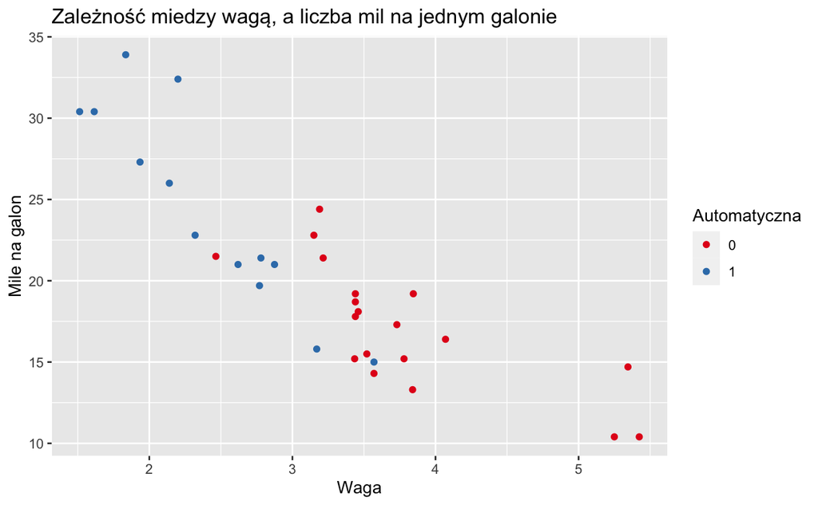

Dodajemy slajd z danymi w formie tabeli

|  | mpg | cyl | disp | hp | drat |
| --- | --- | --- | --- | --- | --- |
| Mazda RX4 | 21.0 | 6 | 160 | 110 | 3.90 |
| Mazda RX4 Wag | 21.0 | 6 | 160 | 110 | 3.90 |
| Datsun 710 | 22.8 | 4 | 108 | 93 | 3.85 |
| Hornet 4 Drive | 21.4 | 6 | 258 | 110 | 3.08 |
| Hornet Sportabout | 18.7 | 8 | 360 | 175 | 3.15 |

Jak można przenieść slajdy? Możemy wykorzystać do tego funkcję `move_slide`

```r
length(prezentacja)
```

```
[1] 6
```

Tworzymy edytowalny wykres

```r
prezentacja <- prezentacja %>%
  add_slide(layout = "Title and Content", master = "Office Theme") %>%
  ph_with(value = wykres_edit, location = ph_location_fullsize())
```

Wczytuję istniejącą prezentację

```r
prez
```

```
pptx document with 7 slide(s)
Available layouts and their associated master(s) are:
```

| layout | master |
| --- | --- |
| Title Slide | Office Theme |
| Title and Content | Office Theme |
| Section Header | Office Theme |
| Two Content | Office Theme |
| Comparison | Office Theme |
| Title Only | Office Theme |
| Blank | Office Theme |